# Risk Factor Analysis

## Outcome Variable

**Outcome Variable:** sstunted

## Predictor Variables

**Intervention Variable:** mhtcm

**Adjustment Set:**

- arm
- W_mage
- meducyrs
- feducyrs
- hhwealth_quart
- single
- delta_W_mage
- delta_meducyrs
- delta_feducyrs
- delta_hhwealth_quart
- delta_single

## Stratifying Variables

The analysis was stratified on these variable(s):

- agecat
- studyid
- country

## Data Summary

| agecat | studyid | country | mhtcm | sstunted | n_cell | n |
| --- | --- | --- | --- | --- | --- | --- |
| Birth | COHORTS | GUATEMALA | >=155 cm | 0 | 110 | 840 |
| Birth | COHORTS | GUATEMALA | >=155 cm | 1 | 0 | 840 |
| Birth | COHORTS | GUATEMALA | <151 cm | 0 | 538 | 840 |
| Birth | COHORTS | GUATEMALA | <151 cm | 1 | 7 | 840 |
| Birth | COHORTS | GUATEMALA | [151-155) cm | 0 | 181 | 840 |
| Birth | COHORTS | GUATEMALA | [151-155) cm | 1 | 4 | 840 |
| Birth | COHORTS | INDIA | >=155 cm | 0 | 522 | 1774 |
| Birth | COHORTS | INDIA | >=155 cm | 1 | 8 | 1774 |
| Birth | COHORTS | INDIA | <151 cm | 0 | 739 | 1774 |
| Birth | COHORTS | INDIA | <151 cm | 1 | 24 | 1774 |
| Birth | COHORTS | INDIA | [151-155) cm | 0 | 470 | 1774 |
| Birth | COHORTS | INDIA | [151-155) cm | 1 | 11 | 1774 |
| Birth | COHORTS | PHILIPPINES | >=155 cm | 0 | 628 | 3050 |
| Birth | COHORTS | PHILIPPINES | >=155 cm | 1 | 2 | 3050 |
| Birth | COHORTS | PHILIPPINES | <151 cm | 0 | 1516 | 3050 |
| Birth | COHORTS | PHILIPPINES | <151 cm | 1 | 29 | 3050 |
| Birth | COHORTS | PHILIPPINES | [151-155) cm | 0 | 860 | 3050 |
| Birth | COHORTS | PHILIPPINES | [151-155) cm | 1 | 15 | 3050 |
| Birth | JiVitA-3 | BANGLADESH | >=155 cm | 0 | 3153 | 22356 |
| Birth | JiVitA-3 | BANGLADESH | >=155 cm | 1 | 164 | 22356 |
| Birth | JiVitA-3 | BANGLADESH | <151 cm | 0 | 11650 | 22356 |
| Birth | JiVitA-3 | BANGLADESH | <151 cm | 1 | 1786 | 22356 |
| Birth | JiVitA-3 | BANGLADESH | [151-155) cm | 0 | 5117 | 22356 |
| Birth | JiVitA-3 | BANGLADESH | [151-155) cm | 1 | 486 | 22356 |
| Birth | Keneba | GAMBIA | >=155 cm | 0 | 1170 | 1431 |
| Birth | Keneba | GAMBIA | >=155 cm | 1 | 17 | 1431 |
| Birth | Keneba | GAMBIA | <151 cm | 0 | 48 | 1431 |
| Birth | Keneba | GAMBIA | <151 cm | 1 | 3 | 1431 |
| Birth | Keneba | GAMBIA | [151-155) cm | 0 | 187 | 1431 |
| Birth | Keneba | GAMBIA | [151-155) cm | 1 | 6 | 1431 |

[output cut: 324 more lines]

The following strata were considered:

- agecat: 24 months, studyid: COHORTS, country: GUATEMALA
- agecat: 24 months, studyid: COHORTS, country: INDIA
- agecat: 24 months, studyid: COHORTS, country: PHILIPPINES
- agecat: 24 months, studyid: JiVitA-3, country: BANGLADESH
- agecat: 24 months, studyid: Keneba, country: GAMBIA
- agecat: 24 months, studyid: LCNI-5, country: MALAWI
- agecat: 24 months, studyid: MAL-ED, country: BANGLADESH
- agecat: 24 months, studyid: MAL-ED, country: BRAZIL
- agecat: 24 months, studyid: MAL-ED, country: INDIA
- agecat: 24 months, studyid: MAL-ED, country: NEPAL
- agecat: 24 months, studyid: MAL-ED, country: PERU
- agecat: 24 months, studyid: MAL-ED, country: SOUTH AFRICA
- agecat: 24 months, studyid: MAL-ED, country: TANZANIA, UNITED REPUBLIC OF
- agecat: 24 months, studyid: NIH-Birth, country: BANGLADESH
- agecat: 24 months, studyid: NIH-Crypto, country: BANGLADESH
- agecat: 24 months, studyid: PROBIT, country: BELARUS
- agecat: 24 months, studyid: PROVIDE, country: BANGLADESH
- agecat: 24 months, studyid: TanzaniaChild2, country: TANZANIA, UNITED REPUBLIC OF
- agecat: 24 months, studyid: ZVITAMBO, country: ZIMBABWE
- agecat: 6 months, studyid: COHORTS, country: GUATEMALA
- agecat: 6 months, studyid: COHORTS, country: INDIA
- agecat: 6 months, studyid: COHORTS, country: PHILIPPINES
- agecat: 6 months, studyid: Guatemala BSC, country: GUATEMALA
- agecat: 6 months, studyid: JiVitA-3, country: BANGLADESH
- agecat: 6 months, studyid: Keneba, country: GAMBIA
- agecat: 6 months, studyid: LCNI-5, country: MALAWI
- agecat: 6 months, studyid: MAL-ED, country: BANGLADESH
- agecat: 6 months, studyid: MAL-ED, country: BRAZIL
- agecat: 6 months, studyid: MAL-ED, country: INDIA
- agecat: 6 months, studyid: MAL-ED, country: NEPAL
- agecat: 6 months, studyid: MAL-ED, country: PERU
- agecat: 6 months, studyid: MAL-ED, country: SOUTH AFRICA
- agecat: 6 months, studyid: MAL-ED, country: TANZANIA, UNITED REPUBLIC OF
- agecat: 6 months, studyid: NIH-Birth, country: BANGLADESH
- agecat: 6 months, studyid: NIH-Crypto, country: BANGLADESH
- agecat: 6 months, studyid: PROBIT, country: BELARUS
- agecat: 6 months, studyid: PROVIDE, country: BANGLADESH
- agecat: 6 months, studyid: SAS-CompFeed, country: INDIA
- agecat: 6 months, studyid: SAS-FoodSuppl, country: INDIA
- agecat: 6 months, studyid: TanzaniaChild2, country: TANZANIA, UNITED REPUBLIC OF
- agecat: 6 months, studyid: ZVITAMBO, country: ZIMBABWE
- agecat: Birth, studyid: COHORTS, country: GUATEMALA
- agecat: Birth, studyid: COHORTS, country: INDIA
- agecat: Birth, studyid: COHORTS, country: PHILIPPINES
- agecat: Birth, studyid: JiVitA-3, country: BANGLADESH
- agecat: Birth, studyid: Keneba, country: GAMBIA
- agecat: Birth, studyid: MAL-ED, country: BANGLADESH
- agecat: Birth, studyid: MAL-ED, country: BRAZIL
- agecat: Birth, studyid: MAL-ED, country: INDIA
- agecat: Birth, studyid: MAL-ED, country: NEPAL
- agecat: Birth, studyid: MAL-ED, country: PERU
- agecat: Birth, studyid: MAL-ED, country: SOUTH AFRICA
- agecat: Birth, studyid: MAL-ED, country: TANZANIA, UNITED REPUBLIC OF
- agecat: Birth, studyid: NIH-Birth, country: BANGLADESH
- agecat: Birth, studyid: NIH-Crypto, country: BANGLADESH
- agecat: Birth, studyid: PROBIT, country: BELARUS
- agecat: Birth, studyid: PROVIDE, country: BANGLADESH
- agecat: Birth, studyid: SAS-CompFeed, country: INDIA
- agecat: Birth, studyid: ZVITAMBO, country: ZIMBABWE

### Dropped Strata

Some strata were dropped due to rare outcomes:

- agecat: Birth, studyid: COHORTS, country: GUATEMALA
- agecat: Birth, studyid: COHORTS, country: PHILIPPINES
- agecat: Birth, studyid: Keneba, country: GAMBIA
- agecat: Birth, studyid: MAL-ED, country: BANGLADESH
- agecat: Birth, studyid: MAL-ED, country: BRAZIL
- agecat: Birth, studyid: MAL-ED, country: INDIA
- agecat: Birth, studyid: MAL-ED, country: NEPAL
- agecat: Birth, studyid: MAL-ED, country: PERU
- agecat: Birth, studyid: MAL-ED, country: SOUTH AFRICA
- agecat: Birth, studyid: MAL-ED, country: TANZANIA, UNITED REPUBLIC OF
- agecat: Birth, studyid: NIH-Birth, country: BANGLADESH
- agecat: Birth, studyid: NIH-Crypto, country: BANGLADESH
- agecat: Birth, studyid: PROBIT, country: BELARUS
- agecat: Birth, studyid: PROVIDE, country: BANGLADESH
- agecat: 6 months, studyid: Guatemala BSC, country: GUATEMALA
- agecat: 6 months, studyid: MAL-ED, country: BANGLADESH
- agecat: 6 months, studyid: MAL-ED, country: BRAZIL
- agecat: 6 months, studyid: MAL-ED, country: INDIA
- agecat: 6 months, studyid: MAL-ED, country: NEPAL
- agecat: 6 months, studyid: MAL-ED, country: PERU
- agecat: 6 months, studyid: MAL-ED, country: SOUTH AFRICA
- agecat: 6 months, studyid: MAL-ED, country: TANZANIA, UNITED REPUBLIC OF
- agecat: 6 months, studyid: NIH-Birth, country: BANGLADESH
- agecat: 6 months, studyid: NIH-Crypto, country: BANGLADESH
- agecat: 6 months, studyid: PROBIT, country: BELARUS
- agecat: 6 months, studyid: PROVIDE, country: BANGLADESH
- agecat: 6 months, studyid: SAS-FoodSuppl, country: INDIA
- agecat: 24 months, studyid: MAL-ED, country: BANGLADESH
- agecat: 24 months, studyid: MAL-ED, country: BRAZIL
- agecat: 24 months, studyid: MAL-ED, country: INDIA
- agecat: 24 months, studyid: MAL-ED, country: NEPAL
- agecat: 24 months, studyid: MAL-ED, country: PERU
- agecat: 24 months, studyid: MAL-ED, country: SOUTH AFRICA
- agecat: 24 months, studyid: NIH-Crypto, country: BANGLADESH
- agecat: 24 months, studyid: PROBIT, country: BELARUS
- agecat: 24 months, studyid: PROVIDE, country: BANGLADESH
- agecat: 24 months, studyid: TanzaniaChild2, country: TANZANIA, UNITED REPUBLIC OF

## Methods Detail

We’re interested in the causal parameters $E[Y_a]$ for all values of $a \in \mathcal{A}$. These parameters represent the mean outcome if, possibly contrary to fact, we intervened to set all units to have $A=a$. Under the randomization and positivity assumptions, these are identified by the statistical parameters $\psi_a=E_W[E_{Y|A,W}(Y|A=a,W)]$. In addition, we’re interested in the mean of $Y$, $E[Y]$ under no intervention (the observed mean). We will estimate these parameters by using SuperLearner to fit the relevant likelihood factors – $E_{Y|A,W}(Y|A=a,W)$ and $p(A=a|W)$, and then updating our likelihood fit using a joint TMLE.

For unadjusted analyses ($W=\{\}$), initial likelihoods were estimated using Lrnr_glm to estimate the simple $E(Y|A)$ and Lrnr_mean to estimate $p(A)$. For adjusted analyses, a small library containing Lrnr_glmnet, Lrnr_xgboost, and Lrnr_mean was used.

Having estimated these parameters, we will then use the delta method to estimate relative risks and attributable risks relative to a prespecified baseline level of $A$.

# Results Detail

## Results Plots

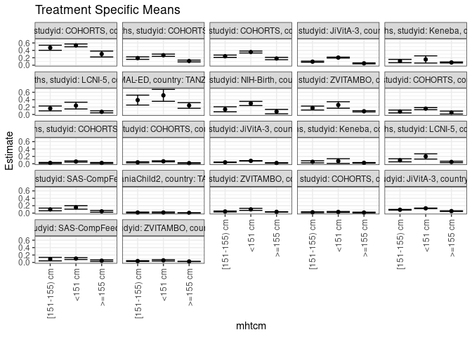

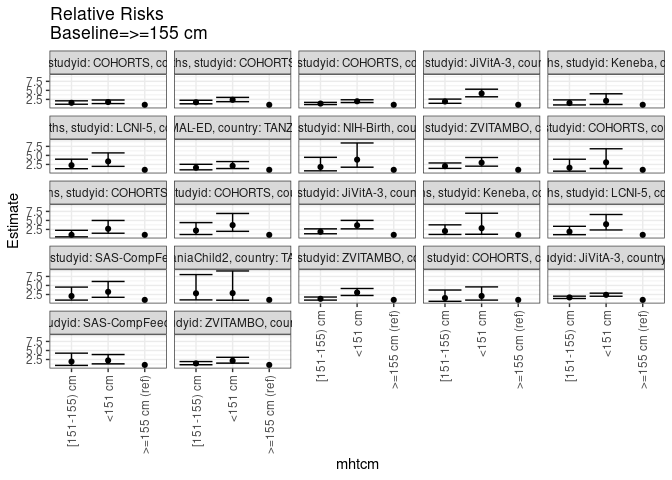

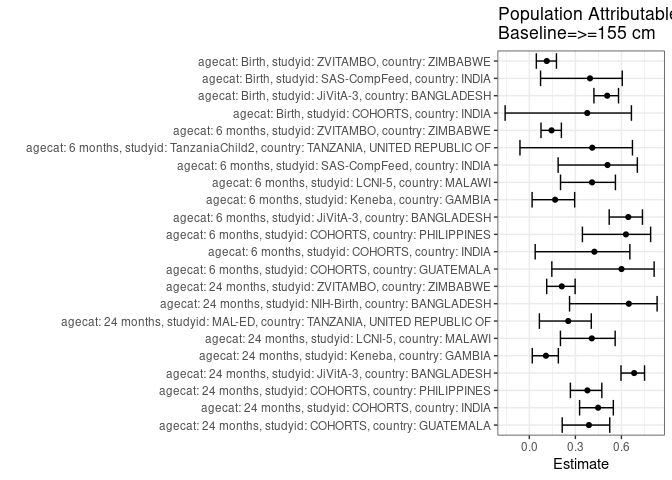

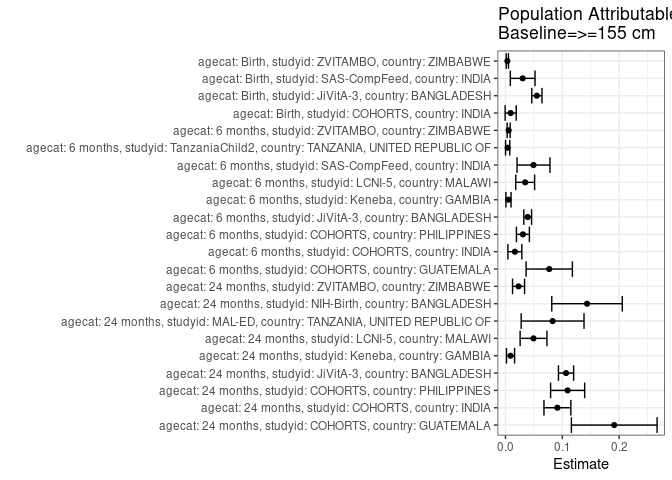

## Results Table

### Parameter: TSM

| agecat | studyid | country | intervention_level | baseline_level | estimate | ci_lower | ci_upper |
| --- | --- | --- | --- | --- | --- | --- | --- |
| Birth | COHORTS | INDIA | >=155 cm | NA | 0.0150943 | 0.0047110 | 0.0254777 |
| Birth | COHORTS | INDIA | <151 cm | NA | 0.0314548 | 0.0190665 | 0.0438431 |
| Birth | COHORTS | INDIA | [151-155) cm | NA | 0.0228690 | 0.0095062 | 0.0362318 |
| Birth | JiVitA-3 | BANGLADESH | >=155 cm | NA | 0.0536892 | 0.0446921 | 0.0626864 |
| Birth | JiVitA-3 | BANGLADESH | <151 cm | NA | 0.1290915 | 0.1228467 | 0.1353364 |
| Birth | JiVitA-3 | BANGLADESH | [151-155) cm | NA | 0.0903915 | 0.0821394 | 0.0986436 |
| Birth | SAS-CompFeed | INDIA | >=155 cm | NA | 0.0463619 | 0.0250675 | 0.0676563 |
| Birth | SAS-CompFeed | INDIA | <151 cm | NA | 0.1039100 | 0.0781316 | 0.1296885 |
| Birth | SAS-CompFeed | INDIA | [151-155) cm | NA | 0.0891440 | 0.0420723 | 0.1362158 |
| Birth | ZVITAMBO | ZIMBABWE | >=155 cm | NA | 0.0258488 | 0.0223103 | 0.0293872 |
| Birth | ZVITAMBO | ZIMBABWE | <151 cm | NA | 0.0558590 | 0.0368615 | 0.0748565 |
| Birth | ZVITAMBO | ZIMBABWE | [151-155) cm | NA | 0.0368488 | 0.0269539 | 0.0467438 |
| 6 months | COHORTS | GUATEMALA | >=155 cm | NA | 0.0512821 | 0.0112934 | 0.0912707 |
| 6 months | COHORTS | GUATEMALA | <151 cm | NA | 0.1573927 | 0.1289181 | 0.1858673 |
| 6 months | COHORTS | GUATEMALA | [151-155) cm | NA | 0.0812183 | 0.0430521 | 0.1193844 |
| 6 months | COHORTS | INDIA | >=155 cm | NA | 0.0224872 | 0.0100358 | 0.0349387 |
| 6 months | COHORTS | INDIA | <151 cm | NA | 0.0605798 | 0.0440205 | 0.0771391 |
| 6 months | COHORTS | INDIA | [151-155) cm | NA | 0.0226975 | 0.0093781 | 0.0360170 |
| 6 months | COHORTS | PHILIPPINES | >=155 cm | NA | 0.0180609 | 0.0073251 | 0.0287967 |
| 6 months | COHORTS | PHILIPPINES | <151 cm | NA | 0.0668736 | 0.0535812 | 0.0801660 |
| 6 months | COHORTS | PHILIPPINES | [151-155) cm | NA | 0.0397354 | 0.0256166 | 0.0538542 |
| 6 months | JiVitA-3 | BANGLADESH | >=155 cm | NA | 0.0215603 | 0.0148722 | 0.0282484 |
| 6 months | JiVitA-3 | BANGLADESH | <151 cm | NA | 0.0787254 | 0.0730069 | 0.0844439 |
| 6 months | JiVitA-3 | BANGLADESH | [151-155) cm | NA | 0.0403148 | 0.0340337 | 0.0465959 |
| 6 months | Keneba | GAMBIA | >=155 cm | NA | 0.0261480 | 0.0182474 | 0.0340485 |
| 6 months | Keneba | GAMBIA | <151 cm | NA | 0.0746269 | 0.0116860 | 0.1375677 |
| 6 months | Keneba | GAMBIA | [151-155) cm | NA | 0.0537190 | 0.0253052 | 0.0821329 |
| 6 months | LCNI-5 | MALAWI | >=155 cm | NA | 0.0502353 | 0.0312173 | 0.0692534 |
| 6 months | LCNI-5 | MALAWI | <151 cm | NA | 0.1985425 | 0.1279517 | 0.2691334 |
| 6 months | LCNI-5 | MALAWI | [151-155) cm | NA | 0.0948707 | 0.0532908 | 0.1364505 |
| 6 months | SAS-CompFeed | INDIA | >=155 cm | NA | 0.0475506 | 0.0233984 | 0.0717029 |
| 6 months | SAS-CompFeed | INDIA | <151 cm | NA | 0.1539445 | 0.1070924 | 0.2007966 |
| 6 months | SAS-CompFeed | INDIA | [151-155) cm | NA | 0.0983804 | 0.0621683 | 0.1345925 |
| 6 months | TanzaniaChild2 | TANZANIA, UNITED REPUBLIC OF | >=155 cm | NA | 0.0056180 | 0.0014669 | 0.0097691 |
| 6 months | TanzaniaChild2 | TANZANIA, UNITED REPUBLIC OF | <151 cm | NA | 0.0161812 | 0.0021097 | 0.0302527 |
| 6 months | TanzaniaChild2 | TANZANIA, UNITED REPUBLIC OF | [151-155) cm | NA | 0.0158730 | 0.0042051 | 0.0275409 |
| 6 months | ZVITAMBO | ZIMBABWE | >=155 cm | NA | 0.0333042 | 0.0287263 | 0.0378820 |
| 6 months | ZVITAMBO | ZIMBABWE | <151 cm | NA | 0.1013922 | 0.0729789 | 0.1298054 |
| 6 months | ZVITAMBO | ZIMBABWE | [151-155) cm | NA | 0.0434179 | 0.0310254 | 0.0558104 |
| 24 months | COHORTS | GUATEMALA | >=155 cm | NA | 0.3015662 | 0.2219873 | 0.3811451 |
| 24 months | COHORTS | GUATEMALA | <151 cm | NA | 0.5348838 | 0.4966340 | 0.5731337 |
| 24 months | COHORTS | GUATEMALA | [151-155) cm | NA | 0.4702647 | 0.4021436 | 0.5383858 |
| 24 months | COHORTS | INDIA | >=155 cm | NA | 0.1125632 | 0.0879454 | 0.1371810 |
| 24 months | COHORTS | INDIA | <151 cm | NA | 0.2689048 | 0.2378775 | 0.2999322 |
| 24 months | COHORTS | INDIA | [151-155) cm | NA | 0.1914493 | 0.1566083 | 0.2262904 |
| 24 months | COHORTS | PHILIPPINES | >=155 cm | NA | 0.1797855 | 0.1478223 | 0.2117488 |
| 24 months | COHORTS | PHILIPPINES | <151 cm | NA | 0.3553853 | 0.3289260 | 0.3818445 |
| 24 months | COHORTS | PHILIPPINES | [151-155) cm | NA | 0.2417836 | 0.2104065 | 0.2731606 |
| 24 months | JiVitA-3 | BANGLADESH | >=155 cm | NA | 0.0494796 | 0.0373562 | 0.0616029 |
| 24 months | JiVitA-3 | BANGLADESH | <151 cm | NA | 0.2048588 | 0.1925136 | 0.2172040 |
| 24 months | JiVitA-3 | BANGLADESH | [151-155) cm | NA | 0.0946473 | 0.0792806 | 0.1100139 |
| 24 months | Keneba | GAMBIA | >=155 cm | NA | 0.0734861 | 0.0595194 | 0.0874528 |
| 24 months | Keneba | GAMBIA | <151 cm | NA | 0.1547289 | 0.0580110 | 0.2514469 |
| 24 months | Keneba | GAMBIA | [151-155) cm | NA | 0.1111554 | 0.0662949 | 0.1560159 |
| 24 months | LCNI-5 | MALAWI | >=155 cm | NA | 0.0719405 | 0.0450094 | 0.0988715 |
| 24 months | LCNI-5 | MALAWI | <151 cm | NA | 0.2401718 | 0.1491180 | 0.3312256 |
| 24 months | LCNI-5 | MALAWI | [151-155) cm | NA | 0.1637485 | 0.0978501 | 0.2296469 |
| 24 months | MAL-ED | TANZANIA, UNITED REPUBLIC OF | >=155 cm | NA | 0.2441747 | 0.1678265 | 0.3205230 |
| 24 months | MAL-ED | TANZANIA, UNITED REPUBLIC OF | <151 cm | NA | 0.5170935 | 0.3562426 | 0.6779444 |
| 24 months | MAL-ED | TANZANIA, UNITED REPUBLIC OF | [151-155) cm | NA | 0.3887225 | 0.2550158 | 0.5224291 |
| 24 months | NIH-Birth | BANGLADESH | >=155 cm | NA | 0.0779221 | 0.0179811 | 0.1378630 |
| 24 months | NIH-Birth | BANGLADESH | <151 cm | NA | 0.2976190 | 0.2411031 | 0.3541350 |
| 24 months | NIH-Birth | BANGLADESH | [151-155) cm | NA | 0.1400000 | 0.0719124 | 0.2080876 |
| 24 months | ZVITAMBO | ZIMBABWE | >=155 cm | NA | 0.0861178 | 0.0694351 | 0.1028005 |
| 24 months | ZVITAMBO | ZIMBABWE | <151 cm | NA | 0.2568635 | 0.1692427 | 0.3444844 |
| 24 months | ZVITAMBO | ZIMBABWE | [151-155) cm | NA | 0.1737838 | 0.1204839 | 0.2270837 |

### Parameter: E(Y)

| agecat | studyid | country | intervention_level | baseline_level | estimate | ci_lower | ci_upper |
| --- | --- | --- | --- | --- | --- | --- | --- |
| Birth | COHORTS | INDIA | NA | NA | 0.0242390 | 0.0170805 | 0.0313975 |
| Birth | JiVitA-3 | BANGLADESH | NA | NA | 0.1089640 | 0.1044122 | 0.1135158 |
| Birth | SAS-CompFeed | INDIA | NA | NA | 0.0766520 | 0.0591565 | 0.0941474 |
| Birth | ZVITAMBO | ZIMBABWE | NA | NA | 0.0291602 | 0.0258126 | 0.0325079 |
| 6 months | COHORTS | GUATEMALA | NA | NA | 0.1283139 | 0.1069569 | 0.1496709 |
| 6 months | COHORTS | INDIA | NA | NA | 0.0390324 | 0.0301298 | 0.0479351 |
| 6 months | COHORTS | PHILIPPINES | NA | NA | 0.0487445 | 0.0406327 | 0.0568562 |
| 6 months | JiVitA-3 | BANGLADESH | NA | NA | 0.0606766 | 0.0568171 | 0.0645361 |
| 6 months | Keneba | GAMBIA | NA | NA | 0.0314331 | 0.0235374 | 0.0393288 |
| 6 months | LCNI-5 | MALAWI | NA | NA | 0.0849282 | 0.0660197 | 0.1038368 |
| 6 months | SAS-CompFeed | INDIA | NA | NA | 0.0969055 | 0.0737418 | 0.1200693 |
| 6 months | TanzaniaChild2 | TANZANIA, UNITED REPUBLIC OF | NA | NA | 0.0095190 | 0.0052582 | 0.0137799 |
| 6 months | ZVITAMBO | ZIMBABWE | NA | NA | 0.0389505 | 0.0345402 | 0.0433608 |
| 24 months | COHORTS | GUATEMALA | NA | NA | 0.4929577 | 0.4618620 | 0.5240535 |
| 24 months | COHORTS | INDIA | NA | NA | 0.2039582 | 0.1854361 | 0.2224803 |
| 24 months | COHORTS | PHILIPPINES | NA | NA | 0.2891616 | 0.2711872 | 0.3071359 |
| 24 months | JiVitA-3 | BANGLADESH | NA | NA | 0.1560647 | 0.1473093 | 0.1648200 |
| 24 months | Keneba | GAMBIA | NA | NA | 0.0823970 | 0.0689280 | 0.0958660 |
| 24 months | LCNI-5 | MALAWI | NA | NA | 0.1213172 | 0.0946538 | 0.1479805 |
| 24 months | MAL-ED | TANZANIA, UNITED REPUBLIC OF | NA | NA | 0.3271028 | 0.2640978 | 0.3901078 |
| 24 months | NIH-Birth | BANGLADESH | NA | NA | 0.2214452 | 0.1821080 | 0.2607825 |
| 24 months | ZVITAMBO | ZIMBABWE | NA | NA | 0.1091703 | 0.0926749 | 0.1256657 |

### Parameter: RR

| agecat | studyid | country | intervention_level | baseline_level | estimate | ci_lower | ci_upper |
| --- | --- | --- | --- | --- | --- | --- | --- |
| Birth | COHORTS | INDIA | >=155 cm | >=155 cm | 1.000000 | 1.0000000 | 1.000000 |
| Birth | COHORTS | INDIA | <151 cm | >=155 cm | 2.083879 | 0.9432426 | 4.603856 |
| Birth | COHORTS | INDIA | [151-155) cm | >=155 cm | 1.515073 | 0.6144022 | 3.736063 |
| Birth | JiVitA-3 | BANGLADESH | >=155 cm | >=155 cm | 1.000000 | 1.0000000 | 1.000000 |
| Birth | JiVitA-3 | BANGLADESH | <151 cm | >=155 cm | 2.404421 | 2.0188702 | 2.863601 |
| Birth | JiVitA-3 | BANGLADESH | [151-155) cm | >=155 cm | 1.683606 | 1.3899552 | 2.039294 |
| Birth | SAS-CompFeed | INDIA | >=155 cm | >=155 cm | 1.000000 | 1.0000000 | 1.000000 |
| Birth | SAS-CompFeed | INDIA | <151 cm | >=155 cm | 2.241280 | 1.2951056 | 3.878707 |
| Birth | SAS-CompFeed | INDIA | [151-155) cm | >=155 cm | 1.922786 | 0.8678880 | 4.259887 |
| Birth | ZVITAMBO | ZIMBABWE | >=155 cm | >=155 cm | 1.000000 | 1.0000000 | 1.000000 |
| Birth | ZVITAMBO | ZIMBABWE | <151 cm | >=155 cm | 2.160996 | 1.4977491 | 3.117947 |
| Birth | ZVITAMBO | ZIMBABWE | [151-155) cm | >=155 cm | 1.425556 | 1.0546129 | 1.926971 |
| 6 months | COHORTS | GUATEMALA | >=155 cm | >=155 cm | 1.000000 | 1.0000000 | 1.000000 |
| 6 months | COHORTS | GUATEMALA | <151 cm | >=155 cm | 3.069157 | 1.3783850 | 6.833887 |
| 6 months | COHORTS | GUATEMALA | [151-155) cm | >=155 cm | 1.583756 | 0.6372270 | 3.936249 |
| 6 months | COHORTS | INDIA | >=155 cm | >=155 cm | 1.000000 | 1.0000000 | 1.000000 |
| 6 months | COHORTS | INDIA | <151 cm | >=155 cm | 2.693962 | 1.4551428 | 4.987437 |
| 6 months | COHORTS | INDIA | [151-155) cm | >=155 cm | 1.009352 | 0.4502858 | 2.262543 |
| 6 months | COHORTS | PHILIPPINES | >=155 cm | >=155 cm | 1.000000 | 1.0000000 | 1.000000 |
| 6 months | COHORTS | PHILIPPINES | <151 cm | >=155 cm | 3.702681 | 1.9790197 | 6.927594 |
| 6 months | COHORTS | PHILIPPINES | [151-155) cm | >=155 cm | 2.200084 | 1.1012310 | 4.395416 |
| 6 months | JiVitA-3 | BANGLADESH | >=155 cm | >=155 cm | 1.000000 | 1.0000000 | 1.000000 |
| 6 months | JiVitA-3 | BANGLADESH | <151 cm | >=155 cm | 3.651406 | 2.6631574 | 5.006375 |
| 6 months | JiVitA-3 | BANGLADESH | [151-155) cm | >=155 cm | 1.869862 | 1.3122402 | 2.664439 |
| 6 months | Keneba | GAMBIA | >=155 cm | >=155 cm | 1.000000 | 1.0000000 | 1.000000 |
| 6 months | Keneba | GAMBIA | <151 cm | >=155 cm | 2.854023 | 1.1651317 | 6.991008 |
| 6 months | Keneba | GAMBIA | [151-155) cm | >=155 cm | 2.054425 | 1.1172215 | 3.777819 |
| 6 months | LCNI-5 | MALAWI | >=155 cm | >=155 cm | 1.000000 | 1.0000000 | 1.000000 |
| 6 months | LCNI-5 | MALAWI | <151 cm | >=155 cm | 3.952249 | 2.3524589 | 6.639977 |
| 6 months | LCNI-5 | MALAWI | [151-155) cm | >=155 cm | 1.888525 | 1.0591783 | 3.367257 |
| 6 months | SAS-CompFeed | INDIA | >=155 cm | >=155 cm | 1.000000 | 1.0000000 | 1.000000 |
| 6 months | SAS-CompFeed | INDIA | <151 cm | >=155 cm | 3.237486 | 1.7175124 | 6.102615 |
| 6 months | SAS-CompFeed | INDIA | [151-155) cm | >=155 cm | 2.068961 | 0.9422193 | 4.543105 |
| 6 months | TanzaniaChild2 | TANZANIA, UNITED REPUBLIC OF | >=155 cm | >=155 cm | 1.000000 | 1.0000000 | 1.000000 |
| 6 months | TanzaniaChild2 | TANZANIA, UNITED REPUBLIC OF | <151 cm | >=155 cm | 2.880259 | 0.9201086 | 9.016209 |
| 6 months | TanzaniaChild2 | TANZANIA, UNITED REPUBLIC OF | [151-155) cm | >=155 cm | 2.825397 | 0.9963933 | 8.011763 |
| 6 months | ZVITAMBO | ZIMBABWE | >=155 cm | >=155 cm | 1.000000 | 1.0000000 | 1.000000 |
| 6 months | ZVITAMBO | ZIMBABWE | <151 cm | >=155 cm | 3.044430 | 2.2281448 | 4.159762 |
| 6 months | ZVITAMBO | ZIMBABWE | [151-155) cm | >=155 cm | 1.303677 | 0.9497011 | 1.789589 |
| 24 months | COHORTS | GUATEMALA | >=155 cm | >=155 cm | 1.000000 | 1.0000000 | 1.000000 |
| 24 months | COHORTS | GUATEMALA | <151 cm | >=155 cm | 1.773686 | 1.3498117 | 2.330668 |
| 24 months | COHORTS | GUATEMALA | [151-155) cm | >=155 cm | 1.559408 | 1.1547399 | 2.105888 |
| 24 months | COHORTS | INDIA | >=155 cm | >=155 cm | 1.000000 | 1.0000000 | 1.000000 |
| 24 months | COHORTS | INDIA | <151 cm | >=155 cm | 2.388923 | 1.8700022 | 3.051843 |
| 24 months | COHORTS | INDIA | [151-155) cm | >=155 cm | 1.700816 | 1.2823889 | 2.255771 |
| 24 months | COHORTS | PHILIPPINES | >=155 cm | >=155 cm | 1.000000 | 1.0000000 | 1.000000 |
| 24 months | COHORTS | PHILIPPINES | <151 cm | >=155 cm | 1.976718 | 1.6319099 | 2.394381 |
| 24 months | COHORTS | PHILIPPINES | [151-155) cm | >=155 cm | 1.344844 | 1.0802127 | 1.674306 |
| 24 months | JiVitA-3 | BANGLADESH | >=155 cm | >=155 cm | 1.000000 | 1.0000000 | 1.000000 |
| 24 months | JiVitA-3 | BANGLADESH | <151 cm | >=155 cm | 4.140271 | 3.2191916 | 5.324890 |
| 24 months | JiVitA-3 | BANGLADESH | [151-155) cm | >=155 cm | 1.912855 | 1.4199018 | 2.576950 |
| 24 months | Keneba | GAMBIA | >=155 cm | >=155 cm | 1.000000 | 1.0000000 | 1.000000 |
| 24 months | Keneba | GAMBIA | <151 cm | >=155 cm | 2.105554 | 1.0956534 | 4.046312 |
| 24 months | Keneba | GAMBIA | [151-155) cm | >=155 cm | 1.512604 | 0.9681396 | 2.363267 |
| 24 months | LCNI-5 | MALAWI | >=155 cm | >=155 cm | 1.000000 | 1.0000000 | 1.000000 |
| 24 months | LCNI-5 | MALAWI | <151 cm | >=155 cm | 3.338480 | 1.9572965 | 5.694307 |
| 24 months | LCNI-5 | MALAWI | [151-155) cm | >=155 cm | 2.276167 | 1.3123722 | 3.947763 |
| 24 months | MAL-ED | TANZANIA, UNITED REPUBLIC OF | >=155 cm | >=155 cm | 1.000000 | 1.0000000 | 1.000000 |
| 24 months | MAL-ED | TANZANIA, UNITED REPUBLIC OF | <151 cm | >=155 cm | 2.117719 | 1.3614902 | 3.293989 |
| 24 months | MAL-ED | TANZANIA, UNITED REPUBLIC OF | [151-155) cm | >=155 cm | 1.591985 | 0.9993758 | 2.535998 |
| 24 months | NIH-Birth | BANGLADESH | >=155 cm | >=155 cm | 1.000000 | 1.0000000 | 1.000000 |
| 24 months | NIH-Birth | BANGLADESH | <151 cm | >=155 cm | 3.819444 | 1.7293940 | 8.435415 |
| 24 months | NIH-Birth | BANGLADESH | [151-155) cm | >=155 cm | 1.796667 | 0.7231383 | 4.463892 |
| 24 months | ZVITAMBO | ZIMBABWE | >=155 cm | >=155 cm | 1.000000 | 1.0000000 | 1.000000 |
| 24 months | ZVITAMBO | ZIMBABWE | <151 cm | >=155 cm | 2.982699 | 2.0141070 | 4.417090 |
| 24 months | ZVITAMBO | ZIMBABWE | [151-155) cm | >=155 cm | 2.017977 | 1.4039778 | 2.900496 |

### Parameter: PAR

| agecat | studyid | country | intervention_level | baseline_level | estimate | ci_lower | ci_upper |
| --- | --- | --- | --- | --- | --- | --- | --- |
| Birth | COHORTS | INDIA | >=155 cm | NA | 0.0091447 | -0.0005835 | 0.0188728 |
| Birth | JiVitA-3 | BANGLADESH | >=155 cm | NA | 0.0552748 | 0.0463135 | 0.0642361 |
| Birth | SAS-CompFeed | INDIA | >=155 cm | NA | 0.0302901 | 0.0085669 | 0.0520132 |
| Birth | ZVITAMBO | ZIMBABWE | >=155 cm | NA | 0.0033115 | 0.0013677 | 0.0052553 |
| 6 months | COHORTS | GUATEMALA | >=155 cm | NA | 0.0770318 | 0.0363083 | 0.1177554 |
| 6 months | COHORTS | INDIA | >=155 cm | NA | 0.0165452 | 0.0042933 | 0.0287971 |
| 6 months | COHORTS | PHILIPPINES | >=155 cm | NA | 0.0306836 | 0.0192773 | 0.0420899 |
| 6 months | JiVitA-3 | BANGLADESH | >=155 cm | NA | 0.0391163 | 0.0322995 | 0.0459330 |
| 6 months | Keneba | GAMBIA | >=155 cm | NA | 0.0052852 | 0.0007603 | 0.0098101 |
| 6 months | LCNI-5 | MALAWI | >=155 cm | NA | 0.0346929 | 0.0181151 | 0.0512707 |
| 6 months | SAS-CompFeed | INDIA | >=155 cm | NA | 0.0493549 | 0.0203924 | 0.0783174 |
| 6 months | TanzaniaChild2 | TANZANIA, UNITED REPUBLIC OF | >=155 cm | NA | 0.0039011 | 0.0001764 | 0.0076257 |
| 6 months | ZVITAMBO | ZIMBABWE | >=155 cm | NA | 0.0056463 | 0.0029859 | 0.0083068 |
| 24 months | COHORTS | GUATEMALA | >=155 cm | NA | 0.1913915 | 0.1159831 | 0.2668000 |
| 24 months | COHORTS | INDIA | >=155 cm | NA | 0.0913950 | 0.0677310 | 0.1150590 |
| 24 months | COHORTS | PHILIPPINES | >=155 cm | NA | 0.1093760 | 0.0794060 | 0.1393461 |
| 24 months | JiVitA-3 | BANGLADESH | >=155 cm | NA | 0.1065851 | 0.0932332 | 0.1199370 |
| 24 months | Keneba | GAMBIA | >=155 cm | NA | 0.0089109 | 0.0017853 | 0.0160364 |
| 24 months | LCNI-5 | MALAWI | >=155 cm | NA | 0.0493767 | 0.0257829 | 0.0729704 |
| 24 months | MAL-ED | TANZANIA, UNITED REPUBLIC OF | >=155 cm | NA | 0.0829281 | 0.0276470 | 0.1382091 |
| 24 months | NIH-Birth | BANGLADESH | >=155 cm | NA | 0.1435231 | 0.0814702 | 0.2055761 |
| 24 months | ZVITAMBO | ZIMBABWE | >=155 cm | NA | 0.0230525 | 0.0124727 | 0.0336323 |

### Parameter: PAF

| agecat | studyid | country | intervention_level | baseline_level | estimate | ci_lower | ci_upper |
| --- | --- | --- | --- | --- | --- | --- | --- |
| Birth | COHORTS | INDIA | >=155 cm | NA | 0.3772707 | -0.1575587 | 0.6649917 |
| Birth | JiVitA-3 | BANGLADESH | >=155 cm | NA | 0.5072755 | 0.4207465 | 0.5808788 |
| Birth | SAS-CompFeed | INDIA | >=155 cm | NA | 0.3951635 | 0.0732251 | 0.6052685 |
| Birth | ZVITAMBO | ZIMBABWE | >=155 cm | NA | 0.1135613 | 0.0456294 | 0.1766579 |
| 6 months | COHORTS | GUATEMALA | >=155 cm | NA | 0.6003391 | 0.1466206 | 0.8128278 |
| 6 months | COHORTS | INDIA | >=155 cm | NA | 0.4238832 | 0.0381500 | 0.6549248 |
| 6 months | COHORTS | PHILIPPINES | >=155 cm | NA | 0.6294786 | 0.3458225 | 0.7901394 |
| 6 months | JiVitA-3 | BANGLADESH | >=155 cm | NA | 0.6446684 | 0.5201810 | 0.7368580 |
| 6 months | Keneba | GAMBIA | >=155 cm | NA | 0.1681403 | 0.0180716 | 0.2952740 |
| 6 months | LCNI-5 | MALAWI | >=155 cm | NA | 0.4084967 | 0.2032488 | 0.5608715 |
| 6 months | SAS-CompFeed | INDIA | >=155 cm | NA | 0.5093095 | 0.1876522 | 0.7036033 |
| 6 months | TanzaniaChild2 | TANZANIA, UNITED REPUBLIC OF | >=155 cm | NA | 0.4098167 | -0.0610110 | 0.6717128 |
| 6 months | ZVITAMBO | ZIMBABWE | >=155 cm | NA | 0.1449621 | 0.0759696 | 0.2088033 |
| 24 months | COHORTS | GUATEMALA | >=155 cm | NA | 0.3882514 | 0.2140877 | 0.5238192 |
| 24 months | COHORTS | INDIA | >=155 cm | NA | 0.4481065 | 0.3273907 | 0.5471571 |
| 24 months | COHORTS | PHILIPPINES | >=155 cm | NA | 0.3782523 | 0.2674783 | 0.4722748 |
| 24 months | JiVitA-3 | BANGLADESH | >=155 cm | NA | 0.6829547 | 0.5972029 | 0.7504507 |
| 24 months | Keneba | GAMBIA | >=155 cm | NA | 0.1081459 | 0.0191271 | 0.1890858 |
| 24 months | LCNI-5 | MALAWI | >=155 cm | NA | 0.4070050 | 0.2026688 | 0.5589749 |
| 24 months | MAL-ED | TANZANIA, UNITED REPUBLIC OF | >=155 cm | NA | 0.2535229 | 0.0655375 | 0.4036914 |
| 24 months | NIH-Birth | BANGLADESH | >=155 cm | NA | 0.6481203 | 0.2620127 | 0.8322203 |
| 24 months | ZVITAMBO | ZIMBABWE | >=155 cm | NA | 0.2111608 | 0.1131381 | 0.2983492 |